# Customer Segmentation

### In this report, we will be aiming at better knowing targeting your audience based on their behaviour and their retention

- Cohort Analysis
- RFM segmentation

# 1- Cohort Analysis

Back to top

```python
import pandas as pd
import numpy as np
import datetime
import matplotlib.pyplot as plt
import seaborn as sns
sns.set(rc={'figure.figsize':(16,8.27)},style="white")
import plotly.express as px
from sklearn.cluster import KMeans
```

```python
df=pd.read_csv('Dataset/online.csv',index_col='Unnamed: 0')
df.head(3)
```

|  | InvoiceNo | StockCode | Description | Quantity | InvoiceDate | UnitPrice | CustomerID | Country |
| --- | --- | --- | --- | --- | --- | --- | --- | --- |
| 416792 | 572558 | 22745 | POPPY'S PLAYHOUSE BEDROOM | 6 | 2011-10-25 08:26:00 | 2.10 | 14286 | United Kingdom |
| 482904 | 577485 | 23196 | VINTAGE LEAF MAGNETIC NOTEPAD | 1 | 2011-11-20 11:56:00 | 1.45 | 16360 | United Kingdom |
| 263743 | 560034 | 23299 | FOOD COVER WITH BEADS SET 2 | 6 | 2011-07-14 13:35:00 | 3.75 | 13933 | United Kingdom |

```python
df['TotalSum']=df['Quantity']*df['UnitPrice']
df['InvoiceDate']=pd.to_datetime(df['InvoiceDate'])
df['InvoiceMonth']=df['InvoiceDate'].dt.strftime("%Y-%m-01")
df['CohorMonth']=df.groupby("CustomerID")['InvoiceMonth'].transform('min')
df['InvoiceMonth']=pd.to_datetime(df['InvoiceMonth'])
df['CohorMonth']=pd.to_datetime(df['CohorMonth'])
df['CohorID']=round((df['InvoiceMonth']-df['CohorMonth'])/np.timedelta64(1,'M')).astype(int)
```

```python
df.head(3)
```

|  | InvoiceNo | StockCode | Description | Quantity | InvoiceDate | UnitPrice | CustomerID | Country | TotalSum | InvoiceMonth | CohorMonth | CohorID |
| --- | --- | --- | --- | --- | --- | --- | --- | --- | --- | --- | --- | --- |
| 416792 | 572558 | 22745 | POPPY'S PLAYHOUSE BEDROOM | 6 | 2011-10-25 08:26:00 | 2.10 | 14286 | United Kingdom | 12.60 | 2011-10-01 | 2011-04-01 | 6 |
| 482904 | 577485 | 23196 | VINTAGE LEAF MAGNETIC NOTEPAD | 1 | 2011-11-20 11:56:00 | 1.45 | 16360 | United Kingdom | 1.45 | 2011-11-01 | 2011-09-01 | 2 |
| 263743 | 560034 | 23299 | FOOD COVER WITH BEADS SET 2 | 6 | 2011-07-14 13:35:00 | 3.75 | 13933 | United Kingdom | 22.50 | 2011-07-01 | 2011-07-01 | 0 |

In this matrix, the intersection between any CohorMonth and CohorID=0 in exactly how many unique customers bought something from the shop for the first time, CohorID from 1 to 12 represent the number of the month passes.

for example:

- 2010-Dec, we had 716 new unique customers, after a month only 246 from the 716 came back and bought again, after 2 months 221 customer come back, and so on.

you can have a good idea on customers retention and wish month had a Succesful marketing campaign that drives loyal new customers.

the next graph shows the percentage of it since it's easier that way to compare

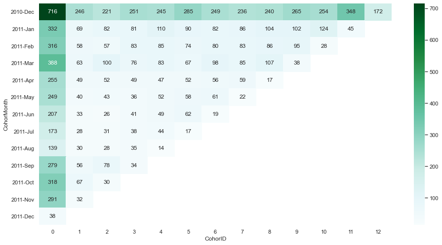

```python
coh=df.groupby(['CohorMonth','CohorID'])['CustomerID'].apply(pd.Series.nunique).unstack()
coh.index=coh.index.strftime('%Y-%b')
sns.heatmap(coh,annot=True,fmt='.3g',cmap='BuGn')
```

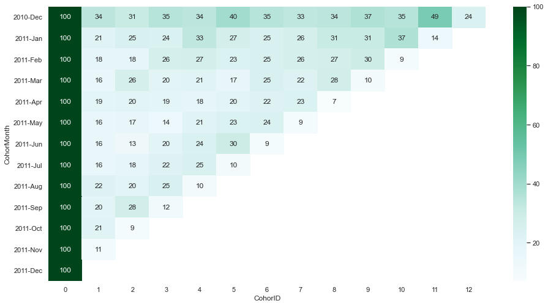

```python
cohp=round(coh.divide(coh[0],axis=0),2)*100
sns.heatmap(cohp,annot=True,fmt='.3g',cmap='BuGn')
```

# 2- RFM segmentation

- Recency (R)
- Frequency (F)
- Monetary Value (M)

Thes 3 matrix is used to group customers base on their value, if we consider clustering our customer into 4 groups on each one of the 3 matrices (RFM) your VIP group will have a score of "444" which translate to:

- Recency score of 4: groups of customers that just bought from your store recently.
- Frequency score of 4: groups of customers that bought from you multiple times the most.
- Monetary Value of 4: groups of customers that spend money the most.

Whit that bieng said there will be diffirent combination of customer that need custom care, for example:

- Customers with 4x4(434,424,414) those customers seem to bought from you recently, they didn't buy from you frequently but they spend a lot of money. it will be preferable so send them a package deal of expensive materials since they are willing to spend a lot of money and not buy a big amount of objects.

And so on.

Back to top

```python
RFM=df.groupby("CustomerID").agg({"InvoiceDate": lambda x: (df['InvoiceDate'].max()-x.max()).days,
                                  "InvoiceNo":"count","TotalSum":"sum"})
RFM.rename(columns = {'InvoiceDate': 'Recency','InvoiceNo': 'Frequency','TotalSum': 'MonetaryValue'}, inplace=True)
RFM['Recency']=RFM['Recency']+1
RFM.head()
```

| CustomerID | Recency | Frequency | MonetaryValue |
| --- | --- | --- | --- |
| 12747 | 2 | 27 | 992.82 |
| 12748 | 1 | 967 | 7522.06 |
| 12749 | 4 | 37 | 813.45 |
| 12820 | 3 | 17 | 268.02 |
| 12822 | 71 | 9 | 146.15 |

```python
RFMS=np.log(RFM)
RFMS=RFMS-RFMS.mean()
RFMS=RFMS/RFMS.std()
RFMS.head()
```

| CustomerID | Recency | Frequency | MonetaryValue |
| --- | --- | --- | --- |
| 12747 | -2.195345 | 0.909398 | 1.482681 |
| 12748 | -2.684191 | 3.844531 | 3.022025 |
| 12749 | -1.706500 | 1.167842 | 1.331210 |
| 12820 | -1.909389 | 0.529933 | 0.487271 |
| 12822 | 0.322084 | 0.008267 | 0.026293 |

```python
RFMS['K']=KMeans(n_clusters=4, random_state=1).fit(RFMS[['Recency', 'Frequency', 'MonetaryValue']]).labels_
RFMS['R']=KMeans(n_clusters=4, random_state=1).fit(RFMS[['Recency']]).labels_
RFMS['F']=KMeans(n_clusters=4, random_state=1).fit(RFMS[['Frequency']]).labels_
RFMS['M']=KMeans(n_clusters=4, random_state=1).fit(RFMS[['MonetaryValue']]).labels_
```

```python
RFMS
```

| CustomerID | Recency | Frequency | MonetaryValue | K | R | F | M |
| --- | --- | --- | --- | --- | --- | --- | --- |
| 12747 | -2.195345 | 0.909398 | 1.482681 | 3 | 1 | 3 | 2 |
| 12748 | -2.684191 | 3.844531 | 3.022025 | 3 | 1 | 1 | 2 |
| 12749 | -1.706500 | 1.167842 | 1.331210 | 3 | 1 | 1 | 2 |
| 12820 | -1.909389 | 0.529933 | 0.487271 | 3 | 1 | 3 | 0 |
| 12822 | 0.322084 | 0.008267 | 0.026293 | 0 | 0 | 3 | 0 |
| ... | ... | ... | ... | ... | ... | ... | ... |
| 18280 | 1.284716 | -1.225445 | -0.983792 | 2 | 2 | 0 | 3 |
| 18281 | 0.982074 | -1.225445 | -1.133066 | 2 | 2 | 0 | 1 |
| 18282 | -1.217655 | -1.225445 | -1.159826 | 1 | 3 | 0 | 1 |
| 18283 | -1.706500 | 2.326817 | 0.851775 | 3 | 1 | 1 | 0 |
| 18287 | -0.031586 | 0.427269 | 0.783538 | 0 | 0 | 3 | 0 |

3701 rows × 7 columns

```python
for coln,col in zip(["K","Recency","Frequency","MonetaryValue"],["K","R","F","M"]):
    if coln=="Recency":
        RFMS.sort_values(by=coln,ascending=True,inplace=True)
    elif coln=="K":
        RFMS.sort_values(by=["Frequency","MonetaryValue"],ascending=False,inplace=True)
    else:
        RFMS.sort_values(by=coln,ascending=False,inplace=True)
    for i,y in zip(RFMS[col].unique(),["a","b","c","d"]):
        RFMS.loc[RFMS[col] == i, col] = y
    for i,y in zip(["a","b","c","d"],[4,3,2,1]):
        RFMS.loc[RFMS[col] == i, col] = y
RFMS.sort_values(by=["K","R","F","M"],ascending=False,inplace=True)
RFMS['RFMS_Sagment']=RFMS['R'].astype(str)+RFMS['F'].astype(str)+RFMS['M'].astype(str)
RFMS['RFMS_Score']=RFMS['R'].astype(int)+RFMS['F'].astype(int)+RFMS['M'].astype(int)
RFMS
```

| CustomerID | Recency | Frequency | MonetaryValue | K | R | F | M | RFMS_Sagment | RFMS_Score |
| --- | --- | --- | --- | --- | --- | --- | --- | --- | --- |
| 18102 | -2.684191 | 1.820594 | 4.595350 | 4 | 4 | 4 | 4 | 444 | 12 |
| 17511 | -1.909389 | 2.522700 | 3.694828 | 4 | 4 | 4 | 4 | 444 | 12 |
| 16684 | -1.706500 | 1.522297 | 3.531796 | 4 | 4 | 4 | 4 | 444 | 12 |
| 14096 | -1.706500 | 3.915972 | 3.455260 | 4 | 4 | 4 | 4 | 444 | 12 |
| 13694 | -1.706500 | 2.105113 | 3.427788 | 4 | 4 | 4 | 4 | 444 | 12 |
| ... | ... | ... | ... | ... | ... | ... | ... | ... | ... |
| 17312 | 0.872709 | -1.225445 | -3.315980 | 1 | 1 | 1 | 1 | 111 | 3 |
| 17343 | 1.457148 | -1.793995 | -3.341750 | 1 | 1 | 1 | 1 | 111 | 3 |
| 16913 | 1.314520 | -1.793995 | -3.593164 | 1 | 1 | 1 | 1 | 111 | 3 |
| 16446 | 1.073319 | -1.793995 | -3.593164 | 1 | 1 | 1 | 1 | 111 | 3 |
| 12977 | 0.877244 | -1.793995 | -4.090248 | 1 | 1 | 1 | 1 | 111 | 3 |

3701 rows × 9 columns

```python
df=pd.merge(RFM,RFMS,left_index=True, right_index=True)
df.sort_values(by=["K","R","F","M"],ascending=False,inplace=True)
df["MonetaryValue_x"]=round(df["MonetaryValue_x"]).astype(int)
df.reset_index(inplace=True)
df
```

|  | CustomerID | Recency_x | Frequency_x | MonetaryValue_x | Recency_y | Frequency_y | MonetaryValue_y | K | R | F | M | RFMS_Sagment | RFMS_Score |
| --- | --- | --- | --- | --- | --- | --- | --- | --- | --- | --- | --- | --- | --- |
| 0 | 12748 | 1 | 967 | 7522 | -2.684191 | 3.844531 | 3.022025 | 4 | 4 | 4 | 4 | 444 | 12 |
| 1 | 12749 | 4 | 37 | 813 | -1.706500 | 1.167842 | 1.331210 | 4 | 4 | 4 | 4 | 444 | 12 |
| 2 | 12839 | 3 | 59 | 1049 | -1.909389 | 1.550584 | 1.524472 | 4 | 4 | 4 | 4 | 444 | 12 |
| 3 | 12841 | 5 | 78 | 714 | -1.549127 | 1.779573 | 1.231712 | 4 | 4 | 4 | 4 | 444 | 12 |
| 4 | 12955 | 1 | 32 | 876 | -2.684191 | 1.048757 | 1.387106 | 4 | 4 | 4 | 4 | 444 | 12 |
| ... | ... | ... | ... | ... | ... | ... | ... | ... | ... | ... | ... | ... | ... |
| 3696 | 18190 | 331 | 2 | 38 | 1.407781 | -1.225445 | -1.005712 | 1 | 1 | 1 | 1 | 111 | 3 |
| 3697 | 18193 | 165 | 2 | 32 | 0.916802 | -1.225445 | -1.117451 | 1 | 1 | 1 | 1 | 111 | 3 |
| 3698 | 18213 | 237 | 2 | 28 | 1.172185 | -1.225445 | -1.232524 | 1 | 1 | 1 | 1 | 111 | 3 |
| 3699 | 18262 | 140 | 1 | 3 | 0.800926 | -1.793995 | -2.958706 | 1 | 1 | 1 | 1 | 111 | 3 |
| 3700 | 18281 | 181 | 2 | 32 | 0.982074 | -1.225445 | -1.133066 | 1 | 1 | 1 | 1 | 111 | 3 |

3701 rows × 13 columns

```python
px.scatter_3d(df,x='Frequency_x',y='MonetaryValue_x',z='Recency_x',color='K',opacity=1,log_x=True,log_y=True,log_z=True)
```

[interactive chart not shown]

```python
px.scatter_3d(df,x='Frequency_x',y='MonetaryValue_x',z='Recency_x',color='RFMS_Score',opacity=1,log_x=True,log_y=True,log_z=True,hover_data=["CustomerID",'Frequency_x','MonetaryValue_x','Recency_x','RFMS_Score',"RFMS_Sagment"])
```

[interactive chart not shown]

Back to top